# The Dataset for this assignment contains some observation on Forest Fires. Since it is not mentioned explicitely, we are assuming the variable "area" is the target variable for this regression problem.

Group Number - 30

Team Members -

1. Chandra Shekaren Sukanya

2. Shivabharathi Ponnuvelu

3. Arup Kumar Pal

Contribution - Equal

# 1. Import libraries and Upload dataset

```python
# Importing required libraries
from google.colab import drive
import calendar
import numpy as np
import pandas as pd
import matplotlib.pyplot as plt
import seaborn as sns
from scipy import stats
from sklearn.preprocessing import MinMaxScaler,StandardScaler
from sklearn.model_selection import train_test_split,KFold
from sklearn.linear_model import LinearRegression
from sklearn.metrics import mean_squared_error,mean_absolute_error, r2_score,get_scorer_names
from statsmodels.tools.eval_measures import rmse
```

```python
#read the data from the given CSV file into a pandas dataframe (df). Here we have uploaded the file first to google drive at same location as this colab ipynb file.

drive.mount('/content/drive') #mount drive
file_path = '/content/drive/MyDrive/Colab Notebooks/forestfires.csv'

df = pd.read_csv(file_path)
```

# 2. Data Visualization and Exploration

### 2.1 Print 2 rows for sanity check to identify all the features present in the dataset and if the target matches with them.

```python
#Print the first 2 rows in the dataframe containing the data
print(df.head(2))
```

```
   X  Y month  day  FFMC   DMC     DC  ISI  temp  RH  wind  rain  area
0  7  5   mar  fri  86.2  26.2   94.3  5.1   8.2  51   6.7   0.0   0.0
1  7  4   oct  tue  90.6  35.4  669.1  6.7  18.0  33   0.9   0.0   0.0
```

```python
# Check the datatypes of the features
df.dtypes
# 2 categorical variables and 11 numerical variables
```

```
X          int64
Y          int64
month     object
day       object
FFMC     float64
DMC      float64
DC       float64
ISI      float64
temp     float64
RH         int64
wind     float64
rain     float64
area     float64
dtype: object
```

```python
# List out column/feature names
df.columns
```

```
Index(['X', 'Y', 'month', 'day', 'FFMC', 'DMC', 'DC', 'ISI', 'temp', 'RH',
       'wind', 'rain', 'area'],
      dtype='object')
```

```python
#Convert the catergorical features Day and Month to numerical values with the help of calendar library
# {jan, feb, mar,...., dec} -> {1,2,3,....,12}
# {mon, tue, wed,...., sun} -> {1,2,3,.....,7}
days = dict((day.lower(),index +1 ) for index, day in enumerate(calendar.day_abbr))
months = dict((month.lower(),index) for index, month in enumerate(calendar.month_abbr))

df['month'] = df.apply(lambda x: months[x['month']], axis=1)
df['day'] = df.apply(lambda x: days[x['day']], axis=1)
```

```python
#check first couple of rows for the acuracy of the convertion
df.head(2)
```

|  | X | Y | month | day | FFMC | DMC | DC | ISI | temp | RH | wind | rain | area |
| --- | --- | --- | --- | --- | --- | --- | --- | --- | --- | --- | --- | --- | --- |
| 0 | 7 | 5 | 3 | 5 | 86.2 | 26.2 | 94.3 | 5.1 | 8.2 | 51 | 6.7 | 0.0 | 0.0 |
| 1 | 7 | 4 | 10 | 2 | 90.6 | 35.4 | 669.1 | 6.7 | 18.0 | 33 | 0.9 | 0.0 | 0.0 |

```python
# Generate descriptive statistics that summarize the central tendency,dispersion and shape of a dataset's distribution
df.describe(include='all')
```

|  | X | Y | month | day | FFMC | DMC | DC | ISI | temp | RH | wind | rain | area |
| --- | --- | --- | --- | --- | --- | --- | --- | --- | --- | --- | --- | --- | --- |
| count | 517.000000 | 517.000000 | 517.000000 | 517.000000 | 517.000000 | 517.000000 | 517.000000 | 517.000000 | 517.000000 | 517.000000 | 517.000000 | 517.000000 | 517.000000 |
| mean | 4.669246 | 4.299807 | 7.475822 | 4.259188 | 90.644681 | 110.872340 | 547.940039 | 9.021663 | 18.889168 | 44.288201 | 4.017602 | 0.021663 | 12.847292 |
| std | 2.313778 | 1.229900 | 2.275990 | 2.072929 | 5.520111 | 64.046482 | 248.066192 | 4.559477 | 5.806625 | 16.317469 | 1.791653 | 0.295959 | 63.655818 |
| min | 1.000000 | 2.000000 | 1.000000 | 1.000000 | 18.700000 | 1.100000 | 7.900000 | 0.000000 | 2.200000 | 15.000000 | 0.400000 | 0.000000 | 0.000000 |
| 25% | 3.000000 | 4.000000 | 7.000000 | 2.000000 | 90.200000 | 68.600000 | 437.700000 | 6.500000 | 15.500000 | 33.000000 | 2.700000 | 0.000000 | 0.000000 |
| 50% | 4.000000 | 4.000000 | 8.000000 | 5.000000 | 91.600000 | 108.300000 | 664.200000 | 8.400000 | 19.300000 | 42.000000 | 4.000000 | 0.000000 | 0.520000 |
| 75% | 7.000000 | 5.000000 | 9.000000 | 6.000000 | 92.900000 | 142.400000 | 713.900000 | 10.800000 | 22.800000 | 53.000000 | 4.900000 | 0.000000 | 6.570000 |
| max | 9.000000 | 9.000000 | 12.000000 | 7.000000 | 96.200000 | 291.300000 | 860.600000 | 56.100000 | 33.300000 | 100.000000 | 9.400000 | 6.400000 | 1090.840000 |

### Following variables has comparatively higher Ranges-

### Area - 0-1091

### DC - 7.9 - 860.6

### Standard Deviation of "Area", "DMC" and "DC" are comparatively higher

```python
#check if any missing values or nans present
nullvalues=df.isnull().sum()
nullvalues

## We do not see any Missing value
```

```
X        0
Y        0
month    0
day      0
FFMC     0
DMC      0
DC       0
ISI      0
temp     0
RH       0
wind     0
rain     0
area     0
dtype: int64
```

## 2.2 Comment on class imbalance with appropriate visualization method.

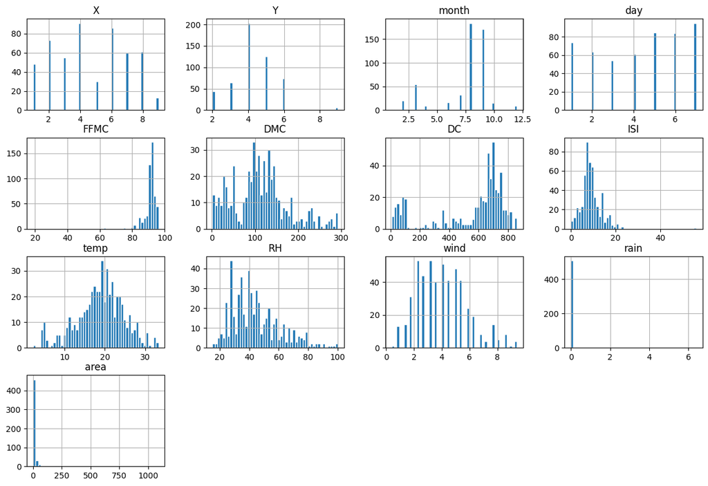

```python
#visualizing distributions with histogram
df.hist(bins=50, figsize=(15,10), ec='w')
plt.show()
```

## From the graphs rain and area look to be heavily skewed towards Zero. These 2 variables are imbalanced. Also, FFMC looks to be skewed as well

Now lets look into the target variable 'area'

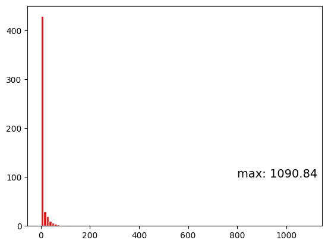

```python
# Plotting a histogram of the 'area' variable alone
plt.hist(df.area, ec='w', bins=100, color='red')
plt.text(800,100, 'max: '+str(df.area.max()), color='black', fontsize=14)
#Burnt area attribute ranges from 0 to 1091.
```

```python
#Grouping the the burnt area to get a better understanding of the data
df['area_cat'] = pd.cut(df['area'], bins=[0,5, 10, 50, 100, 1100], include_lowest=True,
                                 labels=['0-5', '5-10', '10-50', '50-100', '>100'])
print(df.area_cat.value_counts())
```

```
0-5       366
10-50      71
5-10       56
50-100     13
>100       11
Name: area_cat, dtype: int64
```

Target variable area is heavily skewed and we have extreme outliers as well

## Correlation and Data Insight

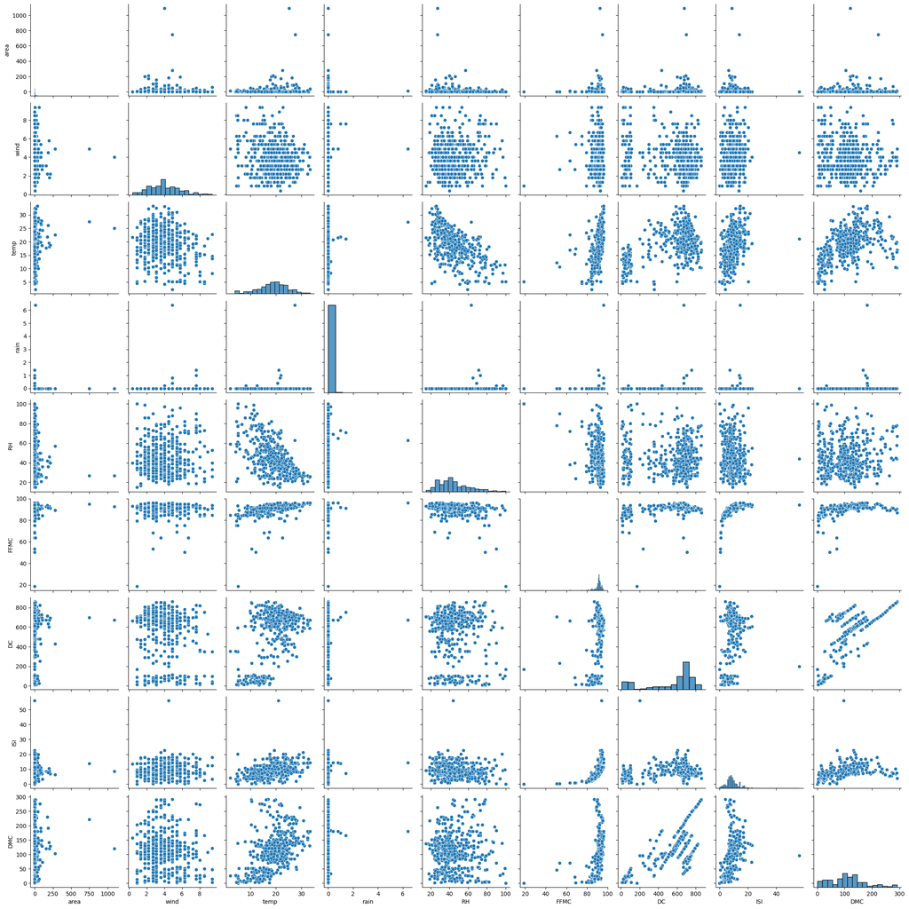

```python
#visualizing relations of most related attributes - this is done without X and Y which are co-ordinates and will not provide any much insight on the data
attributes = ['area', 'wind', 'temp', 'rain', 'RH','FFMC','DC','ISI','DMC']
sns.pairplot(df[attributes])
plt.show()
```

```python
#Obtaining the correlation of the feature set with the target value
correlation = df.corr(method='spearman')['area']
print(correlation)
```

```
X        0.060499
Y        0.046018
month    0.117681
day     -0.016799
FFMC     0.025300
DMC      0.071920
DC       0.061633
ISI      0.012496
temp     0.078696
RH      -0.024221
wind     0.053196
rain    -0.064073
area     1.000000
Name: area, dtype: float64
```

### **Impact of Correlation on the Feature Selection**

The Correlation matrix has immense impact on the feature selection. The features which has no influence on the target variable, should be removed from the final set of features. However, in this scenario, we have observed a lot of Outliers (specially in the target variable). We will first clean up those variables and re-do the correlation before finalizing the required features for our Model

# 3. Data Preprocessing and Cleaning

**a. Outlier Removal - Target Variable**

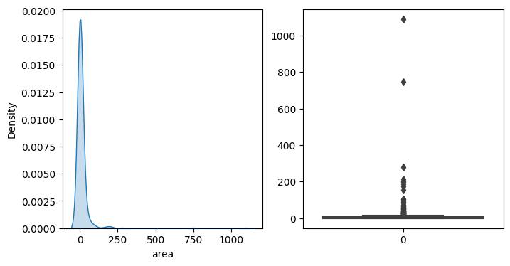

```python
#Plotting the Target variable to check the outliers
fig, ax =plt.subplots(1,2,figsize=(8,4))
sns.kdeplot(df['area'],fill=True,ax=ax[0])
sns.boxplot(df['area'],ax=ax[1])
fig.show()
```

```python
#remove outliers on target variable
df.drop(df[df.area>100].index,axis=0, inplace=True)
df.area_cat.value_counts()
```

```
0-5       366
10-50      71
5-10       56
50-100     13
>100        0
Name: area_cat, dtype: int64
```

**b. Outlier Removal - Rain**

```python
# Remove Outliers from  'Rain'
q_high = df["rain"].quantile(0.99)
df = df[df['rain']<q_high]
```

**c. Outlier Removal - FFMC**

```python
# Remove Outliers from  'FFMC'
q_low = df["FFMC"].quantile(0.01)
df = df[df['FFMC']>q_low]
```

Impact on the Correlation

```python
#Print Correlation after removing outliers from area, rain and FFMC
correlation = df.corr(method='spearman')['area']
print(correlation)
```

```
X        0.055633
Y        0.054411
month    0.101208
day     -0.004442
FFMC     0.020928
DMC      0.052588
DC       0.055452
ISI      0.017230
temp     0.048559
RH       0.007339
wind     0.071484
rain    -0.060564
area     1.000000
Name: area, dtype: float64
```

### Feature Selection Based on the Correlation Matrix

Clearly from the above, the following features have least influence on the target variable

*Day, ISI, RH*

Hence, these can be removed from our Feature Set. For the next steps, we will consider only the following variables as our features

X, Y, month, FFMC, DMC, DC, temp, wind, rain

*To Note, a large negative correlation is just as useful as a large positive correlation. The only difference is that for a positive correlation, as the feature value increases, the target value will also increase. For a negative correlation, as the feature value decreases, the target value will increase.For feature reduction, select features with a correlation close to 0. This means that the feature does not have a useful relationship to the target, and will not help with any prediction.*

```python
# Correlation analysis of the updated feature set
df.corr(method='spearman')
```

|  | X | Y | month | day | FFMC | DMC | DC | ISI | temp | RH | wind | rain | area |
| --- | --- | --- | --- | --- | --- | --- | --- | --- | --- | --- | --- | --- | --- |
| X | 1.000000 | 0.479798 | -0.059948 | -0.014510 | -0.073771 | -0.104785 | -0.071237 | -0.027983 | -0.078549 | 0.063245 | 0.005407 | 0.080414 | 0.055633 |
| Y | 0.479798 | 1.000000 | -0.071759 | -0.012047 | -0.018062 | -0.004449 | -0.099981 | -0.024566 | -0.050795 | 0.052943 | -0.027912 | 0.095749 | 0.054411 |
| month | -0.059948 | -0.071759 | 1.000000 | -0.060284 | 0.186538 | 0.262850 | 0.774559 | 0.053840 | 0.180754 | -0.073411 | -0.121423 | -0.076592 | 0.101208 |
| day | -0.014510 | -0.012047 | -0.060284 | 1.000000 | 0.025682 | 0.036655 | 0.009796 | 0.077101 | 0.073334 | 0.095202 | 0.041580 | -0.012624 | -0.004442 |
| FFMC | -0.073771 | -0.018062 | 0.186538 | 0.025682 | 1.000000 | 0.499215 | 0.266035 | 0.775039 | 0.602758 | -0.328176 | -0.042893 | -0.008360 | 0.020928 |
| DMC | -0.104785 | -0.004449 | 0.262850 | 0.036655 | 0.499215 | 1.000000 | 0.568159 | 0.413157 | 0.498944 | 0.033044 | -0.132982 | 0.003009 | 0.052588 |
| DC | -0.071237 | -0.099981 | 0.774559 | 0.009796 | 0.266035 | 0.568159 | 1.000000 | 0.106115 | 0.313864 | 0.029296 | -0.219642 | -0.071209 | 0.055452 |
| ISI | -0.027983 | -0.024566 | 0.053840 | 0.077101 | 0.775039 | 0.413157 | 0.106115 | 1.000000 | 0.415766 | -0.179681 | 0.127330 | 0.044584 | 0.017230 |
| temp | -0.078549 | -0.050795 | 0.180754 | 0.073334 | 0.602758 | 0.498944 | 0.313864 | 0.415766 | 1.000000 | -0.529982 | -0.202942 | -0.088593 | 0.048559 |
| RH | 0.063245 | 0.052943 | -0.073411 | 0.095202 | -0.328176 | 0.033044 | 0.029296 | -0.179681 | -0.529982 | 1.000000 | 0.021212 | 0.109026 | 0.007339 |
| wind | 0.005407 | -0.027912 | -0.121423 | 0.041580 | -0.042893 | -0.132982 | -0.219642 | 0.127330 | -0.202942 | 0.021212 | 1.000000 | 0.053885 | 0.071484 |
| rain | 0.080414 | 0.095749 | -0.076592 | -0.012624 | -0.008360 | 0.003009 | -0.071209 | 0.044584 | -0.088593 | 0.109026 | 0.053885 | 1.000000 | -0.060564 |
| area | 0.055633 | 0.054411 | 0.101208 | -0.004442 | 0.020928 | 0.052588 | 0.055452 | 0.017230 | 0.048559 | 0.007339 | 0.071484 | -0.060564 | 1.000000 |

## Feature transformation

For the given dataset, we will be using Normalization technique to transform the features. Specifically, we will be using Min-Max Scaling

Justification: Normalization is beneficial when you want to scale the data to a specific range, often between 0 and 1. It preserves the original distribution and relative relationships between the values.

Use case: Normalization is frequently used in algorithms that require input features to be on the same scale, such as neural networks or support vector machines.

For our dataset, the features have multiple different scale (max vs min) and hence we have chosen the above mentioned procedure

```python
#From the previous section, we have already identified the features which we will retain for the model. Combining all the columns we get the feature set
feature_cols = ['area','X','Y','month', 'FFMC', 'DMC', 'DC', 'temp', 'wind', 'rain']

# Create an instance of MinMaxScaler
scaler = MinMaxScaler()
df_normal = pd.DataFrame()

# Apply normalization to the selected columns
df_normal[feature_cols] = scaler.fit_transform(df[feature_cols])
```

```python
# check the first 2 columns
df_normal.head(2)
```

|  | area | X | Y | month | FFMC | DMC | DC | temp | wind | rain |
| --- | --- | --- | --- | --- | --- | --- | --- | --- | --- | --- |
| 0 | 0.0 | 0.75 | 0.428571 | 0.181818 | 0.642857 | 0.082381 | 0.101325 | 0.192926 | 0.700000 | 0.0 |
| 1 | 0.0 | 0.75 | 0.285714 | 0.818182 | 0.800000 | 0.114226 | 0.775419 | 0.508039 | 0.055556 | 0.0 |

```python
#describe the normalized dataset
df_normal.describe()
```

|  | area | X | Y | month | FFMC | DMC | DC | temp | wind | rain |
| --- | --- | --- | --- | --- | --- | --- | --- | --- | --- | --- |
| count | 495.000000 | 495.000000 | 495.000000 | 495.000000 | 495.000000 | 495.000000 | 495.000000 | 495.000000 | 495.000000 | 495.00000 |
| mean | 0.067230 | 0.454545 | 0.327273 | 0.586961 | 0.814062 | 0.372152 | 0.629329 | 0.534886 | 0.400651 | 0.00404 |
| std | 0.146532 | 0.288230 | 0.174622 | 0.208833 | 0.122439 | 0.221960 | 0.294480 | 0.187261 | 0.198936 | 0.06350 |
| min | 0.000000 | 0.000000 | 0.000000 | 0.000000 | 0.000000 | 0.000000 | 0.000000 | 0.000000 | 0.000000 | 0.00000 |
| 25% | 0.000000 | 0.250000 | 0.285714 | 0.545455 | 0.785714 | 0.194704 | 0.495954 | 0.424437 | 0.255556 | 0.00000 |
| 50% | 0.004518 | 0.375000 | 0.285714 | 0.636364 | 0.835714 | 0.366563 | 0.762636 | 0.546624 | 0.400000 | 0.00000 |
| 75% | 0.065140 | 0.750000 | 0.428571 | 0.727273 | 0.882143 | 0.480789 | 0.828427 | 0.662379 | 0.500000 | 0.00000 |
| max | 1.000000 | 1.000000 | 1.000000 | 1.000000 | 1.000000 | 1.000000 | 1.000000 | 1.000000 | 1.000000 | 1.00000 |

# 4. Model Building and Performance Evaluation

## Explicit Splitting of Data into Test and Train

### There are multiple ways to split the data into testing and training set. First, we are going to try the naive method, which is a simple split of the dataset based on the percentage of the rows. We will first try a 80:20 split, which means, the model will train on 80% of the rows and then the model performance will be evaluated on the test data set which is the remaining portion (20%) of the dataset. We will also try 75:25 split and observe the result

Train - Test Split of 80:20

```python
#First spliting our dataframe into feature set (df_normal_corr_cols- all columns except "area") and the target value set(df_normal_labels - "area")

df_normal_corr_cols=df_normal.drop('area', axis=1)
df_normal_labels = pd.DataFrame(df_normal.area.copy())
```

```python
# dividing the data into test and training sets
# test_size denotes 80:20 split of train and test

X_train_n, X_test_n, y_train_n, y_test_n = train_test_split(df_normal_corr_cols, df_normal_labels,test_size=0.2, random_state=42)
X_train_n_work_set = X_train_n.copy() # assigning a copy of train set to work_set
```

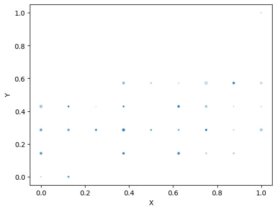

```python
X_train_n_work_set.plot(kind='scatter', x='X', y='Y', alpha=0.2, s=20*y_train_n['area']) # plotting the graphs by increasing the size to see the affect of area over the datapoints
```

```python
lin_reg = LinearRegression()
lin_reg.fit(X_train_n, y_train_n)
```

```
LinearRegression()
```

```python
area_predictions_n = lin_reg.predict(X_test_n)
lin_mse_n = mean_squared_error(y_test_n, area_predictions_n)
lin_rmse_n = np.sqrt(lin_mse_n)
lin_mae_n = mean_absolute_error(y_test_n, area_predictions_n)
lin_r2 = lin_reg.score(X_test_n, y_test_n)

print('linear_train_rmse', lin_rmse_n)
print('Mean Squared Error (MSE):', lin_mse_n)
print('Mean Abs. Error (MAE):', lin_mae_n)
print('R^2 score:', lin_r2)
```

```
linear_train_rmse 0.10691861466970679
Mean Squared Error (MSE): 0.01143159016288924
Mean Abs. Error (MAE): 0.07518070029325648
R^2 score: -0.13230464413850762
```

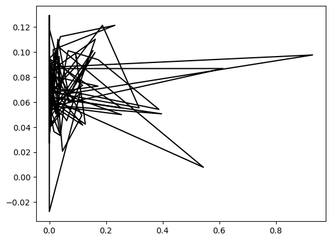

```python
# Plotting actual vs prediction
y_pred_n = lin_reg.predict(X_test_n)
plt.plot(y_test_n, y_pred_n, color ='k')

plt.show()
```

Train - Test Split of 75:25

```python
# dividing the data into test and training sets
# test_size denotes 75:25 split of train and test

X_train_n, X_test_n, y_train_n, y_test_n = train_test_split(df_normal_corr_cols, df_normal_labels,test_size=0.25, random_state=42)
X_train_n_work_set = X_train_n.copy() # assigning a copy of train set to work_set

# fit the model with the training set
lin_reg = LinearRegression()
lin_reg.fit(X_train_n, y_train_n)

# Evaluate and print the Results
area_predictions_n = lin_reg.predict(X_test_n)
lin_mse_n = mean_squared_error(y_test_n, area_predictions_n)
lin_rmse_n = np.sqrt(lin_mse_n)
lin_mae_n = mean_absolute_error(y_test_n, area_predictions_n)
lin_r2 = lin_reg.score(X_test_n, y_test_n)

print('linear_train_rmse', lin_rmse_n)
print('Mean Squared Error (MSE):', lin_mse_n)
print('Mean Abs. Error (MAE):', lin_mae_n)
print('R^2 score:', lin_r2)
```

```
linear_train_rmse 0.13134528959435127
Mean Squared Error (MSE): 0.017251585098623998
Mean Abs. Error (MAE): 0.08194588661411488
R^2 score: -0.04228721354671161
```

## K-Fold Cross Validation

### With K-fold Cross-Validation the dataset is split into a K number of folds and is used to evaluate the model's ability when given new data. K refers to the number of groups the data sample is split into. For our Purpose, we will use a 10 fold cross validation.

```python
X = df_normal.iloc[:, 1:].values
y = df_normal.iloc[:,:1].values
scores=[] #to store r squared
rmse_list=[] #to store RMSE
cv = KFold(n_splits=10, random_state=42, shuffle=True)
for train_index, test_index in cv.split(X):
    X_train_k, X_test_k, y_train_k, y_test_k = X[train_index], X[test_index], y[train_index], y[test_index]
    lin_reg.fit(X_train_k, y_train_k)
    y_predict = lin_reg.predict(X_test_k)
    scores.append(lin_reg.score(X_test_k, y_test_k))
    rmse_fold = rmse(y_test_k, y_predict)
    rmse_list.append(rmse_fold)
print("R Squared Mean: ", np.mean(scores))
print("RMSE mean: ", np.mean(rmse_list))
```

```
R Squared Mean:  -0.03485724146592752
RMSE mean:  0.14424304837884178
```

```python
# Predict on the test data
y_pred_n = lin_reg.predict(X_test_n)

# Calculate evaluation metrics
mae = mean_absolute_error(y_test_n, y_pred_n)
mse = mean_squared_error(y_test_n, y_pred_n)
rmse = np.sqrt(mse)
r2 = r2_score(y_test_n, y_pred_n)

# Display the evaluation metrics
print("Mean Absolute Error (MAE):", mae)
print("Mean Squared Error (MSE):", mse)
print("Root Mean Squared Error (RMSE):", rmse)
print("R-squared (R2) Score:", r2)
```

```
Mean Absolute Error (MAE): 0.07219530487247261
Mean Squared Error (MSE): 0.010751465940424913
Root Mean Squared Error (RMSE): 0.10368927591812431
R-squared (R2) Score: -0.06493800443973008
```

# **Performance Evaluation Observation**

### Mean Absolute Error (MAE): The MAE value of 0.072 indicates that, on average, the model's predictions deviate by approximately 0.072 units from the actual values. Lower MAE values indicate better performance.

### Mean Squared Error (MSE): The MSE value of 0.011 represents the average squared difference between the predicted and actual values. Smaller MSE values indicate better performance.

### Root Mean Squared Error (RMSE): The RMSE value of 0.10 is the square root of MSE and provides an estimate of the average prediction error. Lower RMSE values indicate better performance.

### R-squared (R2) Score: The R2 score of -0.064 measures the proportion of variance in the target variable (area) that can be explained by the model. A negative R2 score suggests that the model performs worse than a horizontal line. Higher R2 scores (closer to 1) indicate better performance.

### Based on the Above, we can conclude the model is fitting few points while some points are completely ignored. Linear Regression might not be a good candidate for this problem. This is most likely because of the low sample size and uneven distribution of variables. Also, we do not have much insight on the domain of this dataset so it is difficult to take decision on Truely impacting variables on the target set. Other regression models (Decision Tree Regression, Random-Forrest, SVM etc.) can be tried to see if this data fits well.